# Grab Safety Analysis

```python
from IPython.core.interactiveshell import InteractiveShell
import pandas as pd
import numpy as np
import matplotlib
import matplotlib.pyplot as plt
import seaborn as sns

# Configure data visualization
InteractiveShell.ast_node_interactivity = "all"
%matplotlib inline
```

# Background and Objective

Safety is an important aspect for online transportation. We want customers to feel safe riding Grab so that they could do other things on the way without worry.

Customers could feel unsafe because of driver's behaviour or driving skill, eg:

- Driver using unpopular shortcuts
- Driver talk with another person on the phone or with customers
- Driver keep seeing GPS and don't pay attention to the road
- Sleepy
- Speeding
- Harsh acceleration, braking, or cornering
- Run over speed bump/hole with high speed

If we could quickly detect when the driver starts driving unsafely, we could remind the driver real-time to prevent something bad happen.

# Raw Data

```python
import glob

def read_csv_from_folder(path_pattern:str, file_limit:int=None):
    """Read csv files from path pattern. Only read file_limit files if it is defined"""
    file_names = glob.glob(path_pattern)
    file_content_list = []

    limit = len(file_names)
    if file_limit is not None:
        limit=min(file_limit, limit)

    print('Reading {} files from "{}" ...'.format(limit, path_pattern))

    for file_name in file_names[:limit]:
        df = pd.read_csv(file_name, index_col=None, header=0)
        file_content_list.append(df)

    contents = pd.concat(file_content_list, axis=0, ignore_index=True)
    del file_content_list
    return contents

features_raw = read_csv_from_folder('../data/features/*.csv', file_limit=2)
labels = read_csv_from_folder('../data/labels/*.csv')
```

```
Reading 2 files from "../data/features/*.csv" ...
Reading 1 files from "../data/labels/*.csv" ...
```

```python
print('Features data sample:')
features_raw.head()
print('Labels data sample:')
labels.head()
```

```
Features data sample:
```

|  | bookingID | Accuracy | Bearing | acceleration_x | acceleration_y | acceleration_z | gyro_x | gyro_y | gyro_z | second | Speed |
| --- | --- | --- | --- | --- | --- | --- | --- | --- | --- | --- | --- |
| 0 | 1202590843006 | 3.000 | 353.0 | 1.228867 | 8.900100 | 3.986968 | 0.008221 | 0.002269 | -0.009966 | 1362.0 | 0.000000 |
| 1 | 274877907034 | 9.293 | 17.0 | 0.032775 | 8.659933 | 4.737300 | 0.024629 | 0.004028 | -0.010858 | 257.0 | 0.190000 |
| 2 | 884763263056 | 3.000 | 189.0 | 1.139675 | 9.545974 | 1.951334 | -0.006899 | -0.015080 | 0.001122 | 973.0 | 0.667059 |
| 3 | 1073741824054 | 3.900 | 126.0 | 3.871543 | 10.386364 | -0.136474 | 0.001344 | -0.339601 | -0.017956 | 902.0 | 7.913285 |
| 4 | 1056561954943 | 3.900 | 50.0 | -0.112882 | 10.550960 | -1.560110 | 0.130568 | -0.061697 | 0.161530 | 820.0 | 20.419409 |

```
Labels data sample:
```

|  | bookingID | label |
| --- | --- | --- |
| 0 | 111669149733 | 0 |
| 1 | 335007449205 | 1 |
| 2 | 171798691856 | 0 |
| 3 | 1520418422900 | 0 |
| 4 | 798863917116 | 0 |

```python
features_raw.loc[features_raw.bookingID==1202590843006,:].sort_values(by='second').head()
```

|  | bookingID | Accuracy | Bearing | acceleration_x | acceleration_y | acceleration_z | gyro_x | gyro_y | gyro_z | second | Speed |
| --- | --- | --- | --- | --- | --- | --- | --- | --- | --- | --- | --- |
| 3054173 | 1202590843006 | 3.014 | 316.0 | 1.271944 | 9.114697 | 3.444433 | -0.008255 | 0.015045 | 0.032358 | 10.0 | 0.000000 |
| 2259509 | 1202590843006 | 3.014 | 316.0 | 1.171215 | 9.357709 | 3.204227 | 0.026110 | 0.004643 | -0.025831 | 11.0 | 0.000000 |
| 2093374 | 1202590843006 | 3.854 | 315.0 | 0.388205 | 9.821781 | 2.394230 | 0.017069 | 0.024976 | -0.006667 | 13.0 | 3.160406 |
| 2916371 | 1202590843006 | 8.505 | 316.0 | 0.611613 | 8.457747 | 3.819527 | 0.038101 | -0.048764 | -0.031276 | 19.0 | 10.009869 |
| 2088652 | 1202590843006 | 9.099 | 315.0 | 1.188625 | 7.354298 | 5.498227 | 0.069464 | 0.091682 | 0.010594 | 23.0 | 10.215185 |

## Feature description

### Booking id

- Trip id
- Possibly relate to service type (GrabCar/Bike) ?

### Accuracy

- Accuracy inferred by GPS in meters
- Affect uncertainty level for GPS Bearing and Speed

### Bearing

- GPS bearing in degree
- The degree of the GPS movement relative from North
- Could relate with GPS accuracy. Less accurate means more uncertainty in the real speed.
- Beware that 10 degree to 340 degrees is 30 degrees difference

### Acceleration (x, y, z)

- Accelerometer reading at a certain axis (m/s2)
- [Youtube explaination about how Accelerometer works](https://www.youtube.com/watch?v=KZVgKu6v808)
- Concern: how could we factor out gravity acceleration.
- Concern: phone orientation

### Gyro (x, y, z)

- Gyroscope reading in certain axis (rad/s)
- Measure angular velocity / speed of rotation
- [Explaination about how Gyroscope works](https://learn.sparkfun.com/tutorials/gyroscope/all)
- Concern: Gyroscope bias, usually caused by heat

### Second

- Time of the record by number of seconds
- Remember that it is not in constant interval, eg: per 2s. If we want to use lag, we need to add for time delta or interpolate it.

### Speed

- Speed measured by GPS in m/s
- Could relate with GPS accuracy. Less accurate means more uncertainty in the real speed.

# Basic Data Preprocess

### Split to train and test set by bookingID

We only split the data to become two sets. Train and test set and we use the test set as the validation set as well. The data is split based on bookingID and before preprocessing to make sure there is no data leak from train to test set.

```python
train_dataset_ratio = 0.7

all_booking_ids = features_raw.bookingID.unique()
np.random.seed(1)
train_booking_id = np.random.choice(all_booking_ids,
                                    size = int(train_dataset_ratio * all_booking_ids.shape[0]),
                                    replace=False)

train_dataset = features_raw.loc[features_raw.bookingID.isin(train_booking_id), :].copy(deep=False)
train_label = labels.loc[labels.bookingID.isin(train_booking_id), :].copy(deep=False)
test_dataset = features_raw.loc[~features_raw.bookingID.isin(train_booking_id), :].copy(deep=False)
test_label = labels.loc[~labels.bookingID.isin(train_booking_id), :].copy(deep=False)
```

```python
print('Safe and un-save trips')
labels.label.value_counts()
print('\n')
print('#BookingID with more than 1 rows in labels: {0}'.format((labels.bookingID.value_counts() > 1).sum()))
```

```
Safe and un-save trips
```

```
0    15017
1     5001
Name: label, dtype: int64
```

```
#BookingID with more than 1 rows in labels: 18
```

### Handle double label

```python
def preproces_label(labels):
    return labels.groupby(['bookingID']).max().reset_index().copy(deep=False)
```

```python
train_label = preproces_label(train_label)
test_label = preproces_label(test_label)
```

# Feature Engineering

### Sequence and Sort

```python
def ensure_sorted(dataset):
    dataset_copy = dataset.copy(deep=False)

    dataset_copy['sequence'] = dataset_copy[
        ['bookingID', 'second']
    ].groupby('bookingID').rank(ascending=True, method='first')

    dataset_copy = dataset_copy.sort_values(by=['bookingID', 'second'])
    return dataset_copy
```

### Gyroscope Data

- Usually phone is not rotating all the time and the value of gyroscope will be 0.
- [Knowing that there is a bias of gyroscope reading](https://base.xsens.com/hc/en-us/articles/209611089-Understanding-Sensor-Bias-offset-), we could use mean to find the expected reading while the phone is in stable position.

```
Gyroscope reading, x-axis bias: gyro_x    0.345862
dtype: float64
```

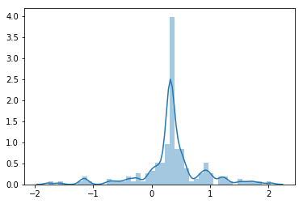

```python
sns.distplot(features_raw.loc[features_raw.bookingID==1477468749954,['gyro_x']])
print('Gyroscope reading, x-axis bias:', features_raw.loc[features_raw.bookingID==1477468749954,['gyro_x']].mean());
```

```python
def gyro_data_enrich(dataset):
    enriched_dataset = dataset.copy(deep=False)
    enriched_dataset = ensure_sorted(enriched_dataset)

    gyro_cols = ['gyro_x', 'gyro_y', 'gyro_z']

    # Find gyroscope bias / stable values
    for col in gyro_cols:
        if (col+'_stable') in enriched_dataset.columns:
            continue
        agg_stable = enriched_dataset.groupby('bookingID')[col].mean().reset_index()
        agg_stable.columns = ['bookingID', col+'_stable']
        enriched_dataset = pd.merge(enriched_dataset, agg_stable, how='left', on='bookingID', validate='m:1', copy=False)

    # Gyroscope filtered / calibrated values
    for col in gyro_cols:
        if (col+'_filtered') in enriched_dataset.columns:
            continue
        enriched_dataset[col+'_filtered'] = enriched_dataset[col] - enriched_dataset[col+'_stable']

    # Gyroscope magnitude of calibrated values
    enriched_dataset['gyro_filtered_magnitude'] = np.sqrt(enriched_dataset['gyro_x_filtered']**2 + \
                                                          enriched_dataset['gyro_y_filtered']**2 + \
                                                          enriched_dataset['gyro_z_filtered']**2)

    # Gyroscope magnitude standard deviation
    agg_std = enriched_dataset.groupby('bookingID')['gyro_filtered_magnitude'].std().reset_index()
    agg_std.columns = ['bookingID', 'gyro_filtered_std']
    enriched_dataset = pd.merge(enriched_dataset, agg_std, how='left', on='bookingID', validate='m:1', copy=False)

    return enriched_dataset
```

```python
# gyro_data_enrich(train_dataset).head()
```

### Accelerometer Data

- Accelerometer readings depends on gravity
- [Phone orientation](https://www.digikey.com/en/articles/techzone/2011/may/using-an-accelerometer-for-inclination-sensing) could change over time and change the gravity acceleration for each axis

Could we?

- Handle accelerometer bias? Gravity is not always 9.8. It depends on altitude and accelerometer bias.
- Distinguish between vehicle movement and user moving the phone?
- Normalize all data assuming all phones are having the same orientation?

```python
def accel_data_enrich(dataset, smoothing: int=3):
    enriched_dataset = dataset.copy(deep=False)
    enriched_dataset = ensure_sorted(enriched_dataset)

    accel_cols = pd.Series(['acceleration_x', 'acceleration_y', 'acceleration_z'])

    # Rolling mean of accleration data to find gravity
    rolling_mean_data = enriched_dataset.groupby('bookingID').apply(
        lambda x: x[
            accel_cols
        ].rolling(window=smoothing, min_periods=1, center=True).mean())
    rolling_mean_data.columns = accel_cols + '_gravity'
    enriched_dataset = pd.concat([enriched_dataset, rolling_mean_data], axis=1, verify_integrity=True)

    # Acceleration magnitude
    enriched_dataset['acceleration_magnitude'] = np.sqrt(enriched_dataset['acceleration_x']**2 + \
                                                         enriched_dataset['acceleration_y']**2 + \
                                                         enriched_dataset['acceleration_z']**2)

    # Current acceleration vs gravity diff
    for col in accel_cols:
        enriched_dataset[col+'_gravity_diff'] = enriched_dataset[col] - enriched_dataset[col+'_gravity']
    enriched_dataset['acceleration_gravity_diff_magnitude'] = np.sqrt(enriched_dataset['acceleration_x_gravity_diff']**2 + \
                                                                      enriched_dataset['acceleration_y_gravity_diff']**2 + \
                                                                      enriched_dataset['acceleration_z_gravity_diff']**2)

    # Acceleration magnitude standard deviation
    agg_std = enriched_dataset.groupby('bookingID')['acceleration_magnitude', 'acceleration_gravity_diff_magnitude'].std().reset_index()
    agg_std.columns = ['bookingID', 'acceleration_std', 'acceleration_gravity_diff_std']
    enriched_dataset = pd.merge(enriched_dataset, agg_std, how='left', on='bookingID', validate='m:1', copy=False)

    # Phone orientation
    enriched_dataset['orientation_theta'] = np.arctan(enriched_dataset.acceleration_x_gravity / \
        np.sqrt(enriched_dataset.acceleration_y_gravity**2 + enriched_dataset.acceleration_z_gravity**2)) / np.pi * 360
    enriched_dataset['orientation_psi'] = np.arctan(enriched_dataset.acceleration_y_gravity / \
        np.sqrt(enriched_dataset.acceleration_x_gravity**2 + enriched_dataset.acceleration_z_gravity**2)) / np.pi * 360
    enriched_dataset['orientation_phi'] = np.arctan( np.sqrt(enriched_dataset.acceleration_x_gravity**2 + enriched_dataset.acceleration_y_gravity**2) / \
        enriched_dataset.acceleration_z_gravity ) / np.pi * 360

    return enriched_dataset
```

```python
# accel_data_enrich(train_dataset).head()
```

### Sequence Difference Data and Aggregation

```python
def diff_data_enrich(dataset):
    enriched_dataset = dataset.copy(deep=False)
    enriched_dataset = ensure_sorted(enriched_dataset)

    # Construct diff
    diff_data = enriched_dataset.groupby('bookingID')['second','Bearing','Speed'].diff()
    diff_data = diff_data.rename(columns = lambda x: x + '_diff')

    # Modify Bearing diff to -180 to 180
    diff_data.Bearing_diff = diff_data.Bearing_diff
    diff_data.Bearing_diff[diff_data.Bearing_diff < -180.0] += 180
    diff_data.Bearing_diff[diff_data.Bearing_diff > 180.0] -= 180

    # Difference / second (normalization)
    diff_data['Bearing_dps'] = diff_data['Bearing_diff'] / diff_data['second_diff']
    diff_data['Speed_dps'] = diff_data['Speed_diff'] / diff_data['second_diff']

    # Combine
    diff_data = diff_data.fillna(0)
    enriched_dataset = pd.concat([enriched_dataset, diff_data], axis=1, verify_integrity=True)

    # Combine accuracy of two sequence
    acc_sum = enriched_dataset.groupby('bookingID')['Accuracy']\
       .rolling(window=2, min_periods=1).sum().reset_index(drop=True).tolist()
    enriched_dataset['Accuracy_sum'] = acc_sum

    return enriched_dataset
```

```python
# diff_data_enrich(train_dataset)
```

```python
def aggregate_data(preprocessed_dataset):
    features_max = ['gyro_filtered_magnitude',
                    'acceleration_magnitude',
                    'Speed',
                    'Bearing_dps',
                    'Speed_dps',
                    'Accuracy_sum',
                    'second',
                    'sequence',
                    'acceleration_x_gravity_diff',
                    'acceleration_y_gravity_diff',
                    'acceleration_z_gravity_diff',
                    'acceleration_gravity_diff_magnitude',
                    'gyro_x_filtered',
                    'gyro_y_filtered',
                    'gyro_z_filtered']

    agg_max = preprocessed_dataset.groupby('bookingID')[features_max].max().reset_index()
    agg_max.columns = ['bookingID'] +  (pd.Series(features_max) + '_max').tolist()

    features_std = ['gyro_filtered_magnitude', 'acceleration_gravity_diff_magnitude']
    agg_std = preprocessed_dataset.groupby('bookingID')[features_std].std().reset_index()
    agg_std.columns = ['bookingID'] +  (pd.Series(features_std) + '_std').tolist()

    agg_data = pd.merge(agg_max, agg_std, on='bookingID', validate='1:1')
    agg_data['second_sequence_ratio'] = agg_data['second_max'] / agg_data['sequence_max'].astype(float)
    return agg_data
```

```python
def preprocess(dataset):
    dataset = gyro_data_enrich(dataset)
    dataset = accel_data_enrich(dataset, smoothing=5)
    dataset = diff_data_enrich(dataset)
    return dataset
```

# Analysis

```python
train_dataset_prep = preprocess(train_dataset)
```

## Charting

```python
def chart_trip(dataset, booking_id):
    booking_id_data = dataset.loc[dataset.bookingID==booking_id,:].sort_values(by='second')

    plt.figure(figsize=(15,10))
    plt.subplots_adjust(hspace = .001)

    # Acceleration
    booking_id_acc = booking_id_data[
        ['second','acceleration_x', 'acceleration_y','acceleration_z', 'acceleration_magnitude']
    ].melt(id_vars=["second"], var_name="axis", value_name="value")
    ax1 = plt.subplot('311')

    plt.title("Measured data for booking ID: {}".format(booking_id))
    sns.lineplot(x="second", y="value", hue='axis', data=booking_id_acc, ax=ax1, marker="o");

    # Gyroscope
    booking_id_gyro = booking_id_data[
        ['second', 'gyro_x', 'gyro_y', 'gyro_z']
    ].melt(id_vars=["second"], var_name="axis", value_name="value")
    ax2 = plt.subplot('312')
    sns.lineplot(x="second", y="value", hue='axis', data=booking_id_gyro, ax=ax2, markers=True, marker="o");

    # Speed
    booking_id_speed = booking_id_data[
        ['second', 'Speed', 'Accuracy']
    ].melt(id_vars=["second"], var_name="type", value_name="value")
    ax3 = plt.subplot('313')
    sns.lineplot(x='second', y="value", hue='type', data=booking_id_speed, ax=ax3, markers=True, marker="o")
```

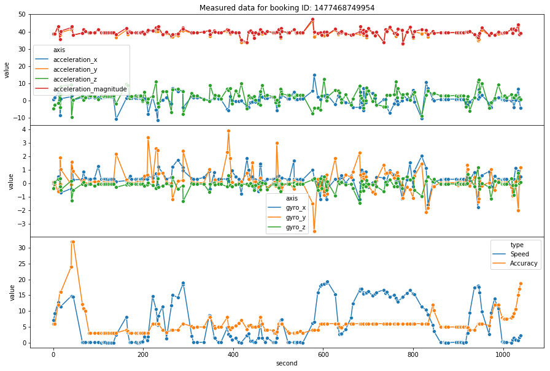

```python
chart_trip(train_dataset_prep, 1477468749954)
```

### Sample of non-safe trip

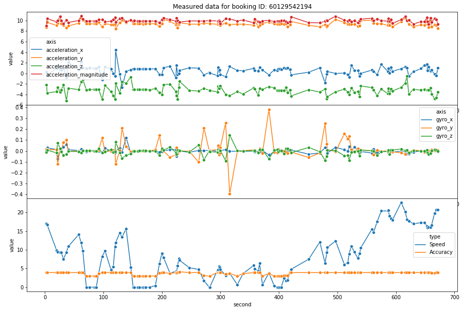

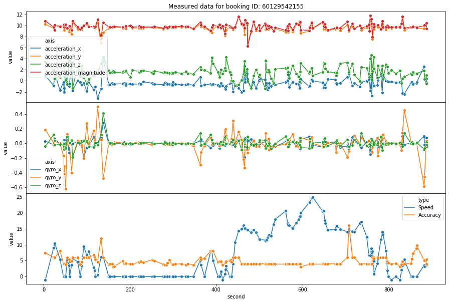

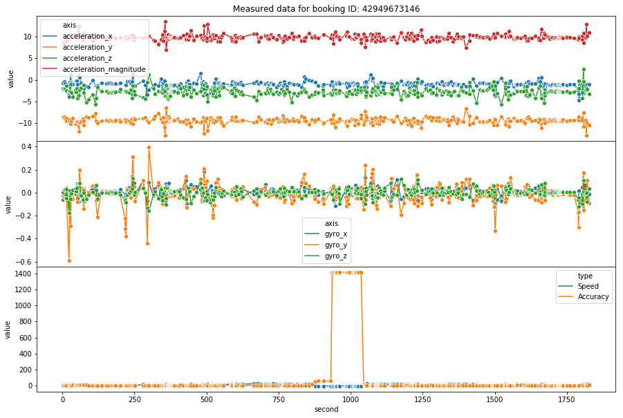

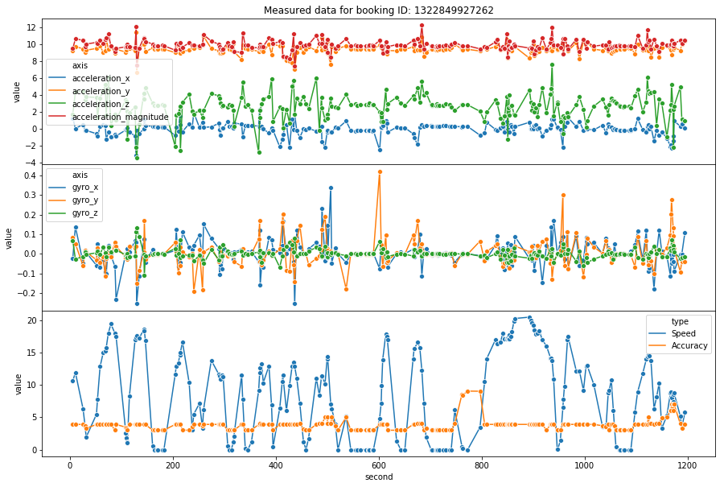

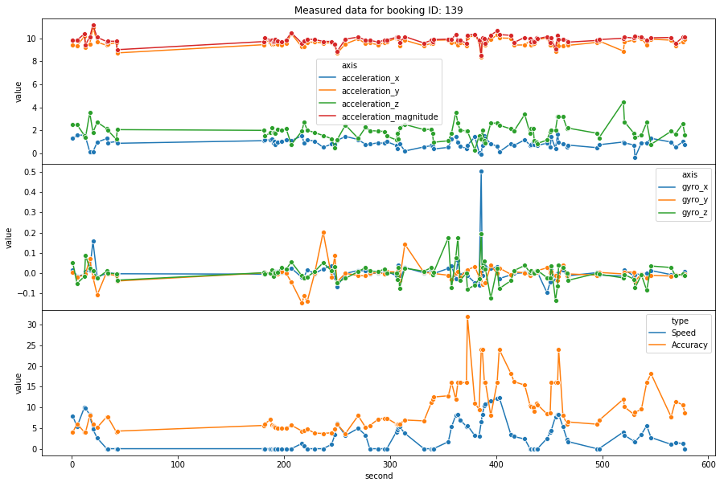

```python
samp = train_label.bookingID[train_label.label == 1].sample(5, random_state=2)
for id in samp:
    chart_trip(train_dataset_prep, id)
```

### Sample of safe trip

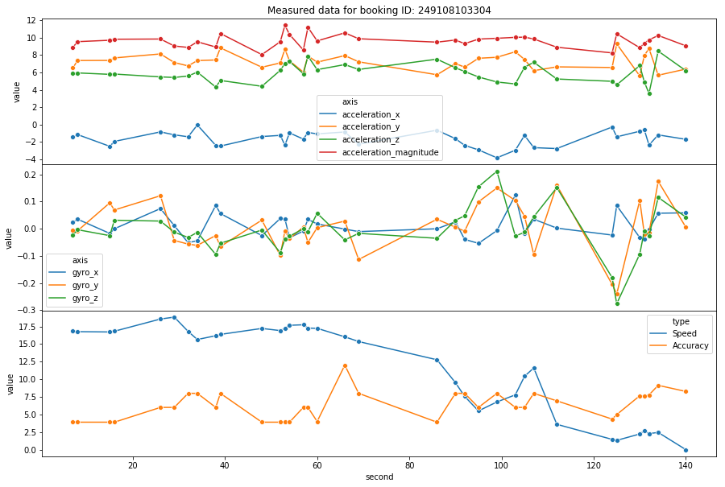

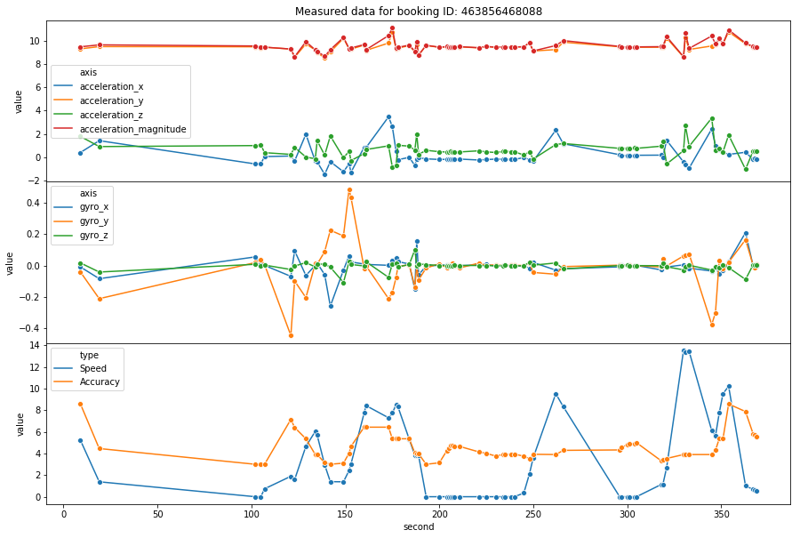

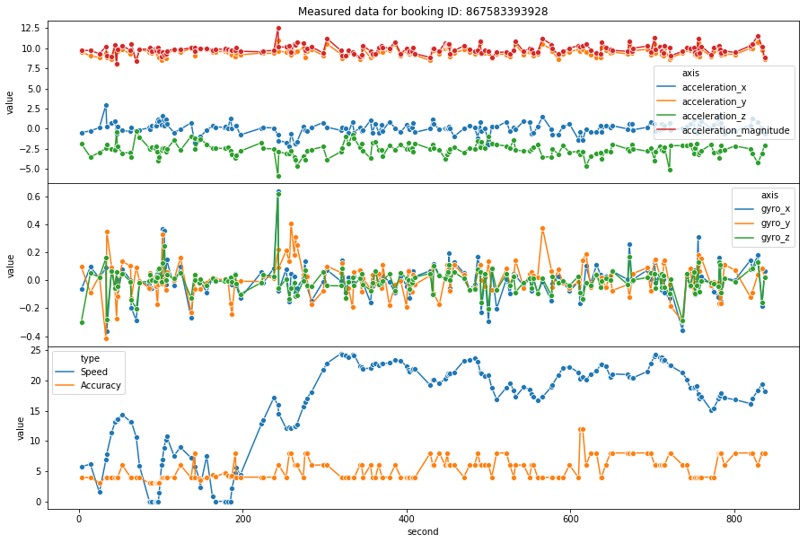

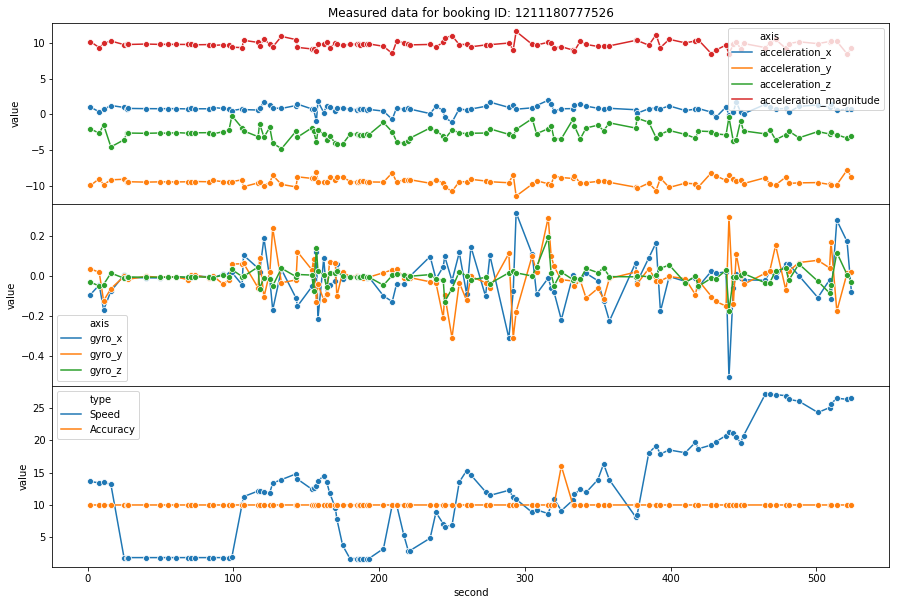

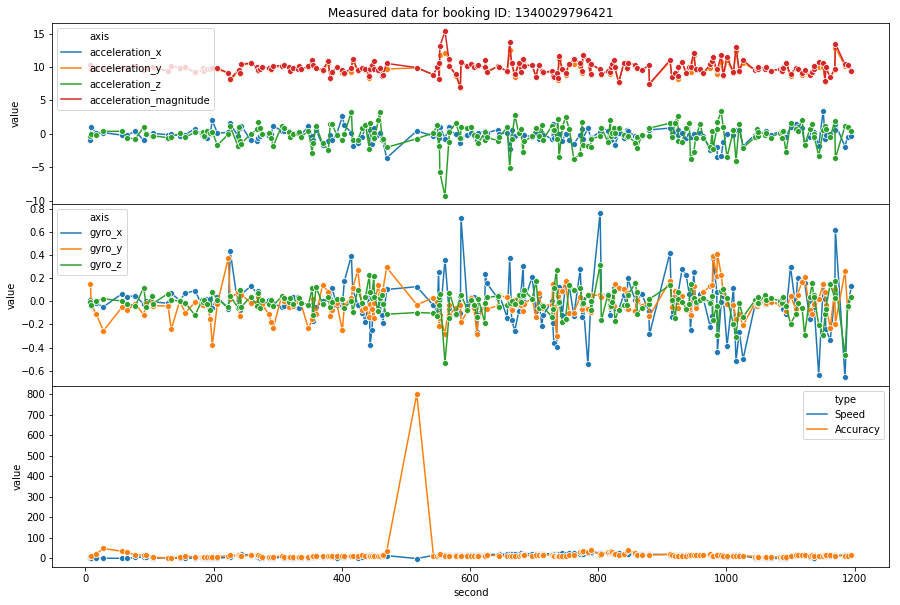

```python
samp = train_label.bookingID[train_label.label == 0].sample(5, random_state=2)
for id in samp:
    chart_trip(train_dataset_prep, id)
```

## Correlation

```python
analytics_features = ['gyro_filtered_magnitude',
                      'acceleration_magnitude',
                      'Speed',
                      'Bearing_dps',
                      'Speed_dps',
                      'second_diff',
                      'second',
                      'Accuracy_sum',
                      'acceleration_x',
                      'acceleration_y',
                      'acceleration_z',
                      'acceleration_x_gravity_diff',
                      'acceleration_y_gravity_diff',
                      'acceleration_z_gravity_diff',
                      'acceleration_gravity_diff_magnitude',
                      'gyro_x_filtered',
                      'gyro_y_filtered',
                      'gyro_z_filtered']
```

### Mean correlation

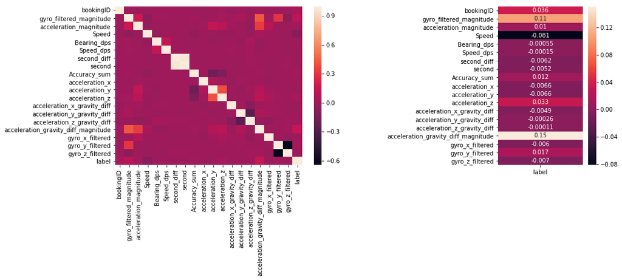

```python
analytics_mean_corr = train_dataset_prep.groupby('bookingID')[analytics_features].mean().reset_index()
analytics_mean_corr = pd.merge(analytics_mean_corr, train_label, on='bookingID')
analytics_mean_corr = analytics_mean_corr.corr()

plt.figure( figsize=(15,5) )
ax1 = plt.subplot2grid((1, 4), (0, 0), colspan=2)
ax2 = plt.subplot2grid((1, 4), (0, 3), colspan=1)
sns.heatmap(analytics_mean_corr, ax=ax1)
sns.heatmap(pd.DataFrame(analytics_mean_corr.loc[analytics_mean_corr.index != 'label','label']), annot=True, ax=ax2);
```

This correlation table shows that mean/average data is less effective to determine a trip is save or unsafe. The unsafe tracking event maybe only recorded 1 time or maybe < 5% of the trip. But, acceleration and gyroscope magnitude data stand out here. How many % of the trips where the driver consistently drive unsafely?

### Max correlation

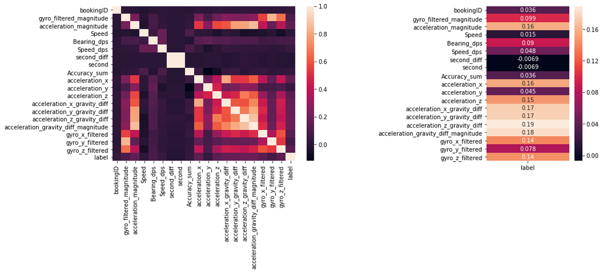

```python
analytics_max_corr = train_dataset_prep.groupby('bookingID')[analytics_features].max().reset_index()
analytics_max_corr = pd.merge(analytics_max_corr, train_label, on='bookingID')
analytics_max_corr = analytics_max_corr.corr()

plt.figure( figsize=(15,5) )
ax1 = plt.subplot2grid((1, 4), (0, 0), colspan=2)
ax2 = plt.subplot2grid((1, 4), (0, 3), colspan=1)
sns.heatmap(analytics_max_corr, ax=ax1)
sns.heatmap(pd.DataFrame(analytics_max_corr.loc[analytics_max_corr.index != 'label','label']), annot=True, ax=ax2);
```

### Standard deviation correlation

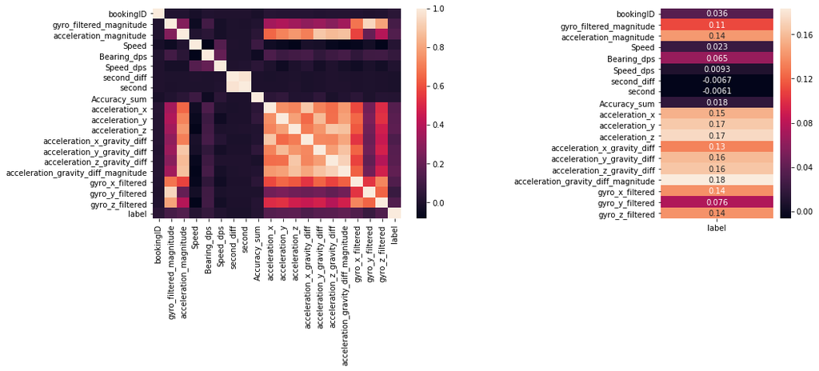

```python
analytics_std_corr = train_dataset_prep.groupby('bookingID')[analytics_features].std().reset_index()
analytics_std_corr = pd.merge(analytics_std_corr, train_label, on='bookingID')
analytics_std_corr = analytics_std_corr.corr()

plt.figure( figsize=(15,5) )
ax1 = plt.subplot2grid((1, 4), (0, 0), colspan=2)
ax2 = plt.subplot2grid((1, 4), (0, 3), colspan=1)
sns.heatmap(analytics_std_corr, ax=ax1)
sns.heatmap(pd.DataFrame(analytics_std_corr.loc[analytics_std_corr.index != 'label','label']), annot=True, ax=ax2);
```

Gyro and acceleration standard deviation is highly correlated. The hypothesis is when there is angular velocity (gyroscope reading), the phone orientation is changing. Hence, the direction of gravity relative to the phone is changing and the reading for each accelerometer axis is changing too.

Because it is highly correlated, we will just use subset of it:

- gyroscope filter magnitude's standard deviation
- acceleration gravity diff magnitude's standard deviation

## Others

### Could we cluster the trips?

```python
train_agg_data = aggregate_data(train_dataset_prep)
train_agg_data = pd.merge(train_agg_data, train_label, on='bookingID', validate='1:1')
```

```python
from sklearn import preprocessing
from sklearn.decomposition import PCA
```

```python
features = train_agg_data.columns[train_agg_data.columns.str.contains("max|std")]

std_scaler = preprocessing.StandardScaler()
x = std_scaler.fit_transform(train_agg_data[features])

pca = PCA(n_components=2)
pc = pca.fit_transform(x)
pc_df = pd.DataFrame(data = pc, columns = ['pc1', 'pc2'])
```

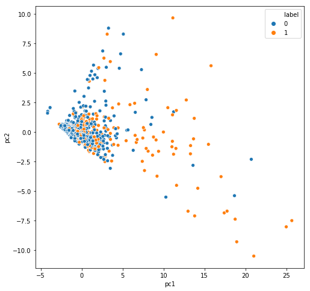

```python
plt.figure(figsize=(8, 8))
sns.scatterplot(x="pc1",
                y="pc2",
                hue="label",
                data=pd.concat([train_agg_data, pc_df], axis=1, verify_integrity=True).sample(2000));
```

There are **no visually standout clusters** after we reduce the features to 2-dimension with PCA.

### Does trip duration effects safety?

There are two possibilities (hypothesis)

1. Longer trips increase the probability to encounter non-safe events
2. There are trips with a duration of < 2 minutes. Probably short duration trips are cancelled trips and that is why most of them are safe trips.

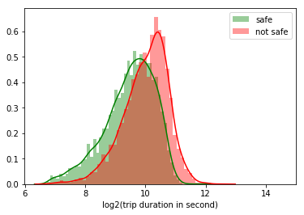

```python
sns.distplot(np.log2(train_agg_data.loc[(train_agg_data.label == 0) & (train_agg_data.second_max < 7200)].second_max),
             label='safe', color='green')
sns.distplot(np.log2(train_agg_data.loc[(train_agg_data.label == 1) & (train_agg_data.second_max < 7200)].second_max),
             label='not safe', color='red')
plt.xlim(xmax=15)
plt.xlabel('log2(trip duration in second)')
plt.legend();
```

```python
bins =  [i for i in range(0,(40+1),2)] # List of 0, 2,4,6 .., 40
df_pct_area = train_agg_data.loc[train_agg_data.second_max < (40*60), ['bookingID','second_max', 'label']]
df_pct_area['duration_min'] = df_pct_area.second_max / 60.0
df_pct_area['2min_bin'] = pd.cut(df_pct_area['duration_min'], bins=bins, labels=bins[:-1])
df_pct_area = pd.pivot_table(df_pct_area, values='bookingID', aggfunc=lambda x: x.shape[0], index='2min_bin', columns='label')
df_pct_area = df_pct_area.divide(df_pct_area.sum(axis=1), axis=0)
```

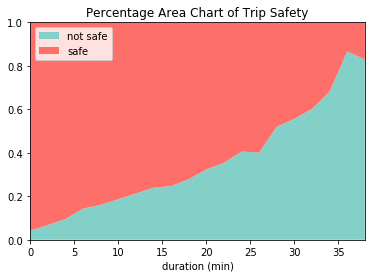

```python
# Make the plot
plt.stackplot(range(0,40,2),  df_pct_area[1],  df_pct_area[0], labels=['not safe','safe'],
              colors=['#83d0c9','#ff6f69'])
plt.legend(loc='upper left')
plt.margins(0,0)
plt.title('Percentage Area Chart of Trip Safety')
plt.xlabel('duration (min)')
plt.show();
```

Additionally, after seeing the smoothness of the chart, this data seems like a little bit odd. Seeing the pattern, there is a hypothesis that the label is produced by other machine learning model which have an additive effect. The model predicts each segment of the trip and adds up the unsafeness. I think using trip duration feature to train and predict is like some kind of "cheat" and we should not use it in the real case.

### Does tracking rate have corellation with label?

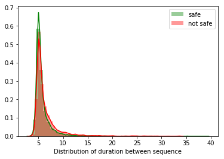

```python
sns.distplot(train_agg_data.loc[(train_agg_data.label == 0) & (train_agg_data.second_sequence_ratio < 40.0)].second_sequence_ratio,
             label='safe', color='green')
sns.distplot(train_agg_data.loc[(train_agg_data.label == 1) & (train_agg_data.second_sequence_ratio < 40.0)].second_sequence_ratio,
             label='not safe', color='red')
plt.xlabel('Distribution of duration between sequence')
plt.legend();
```

There is almost no difference in event logging rate between labels.

# Modeling

Our goal is to make the model which is capable to find the pattern of non-safe event like:

- Driver using unpopular shortcuts
- Driver talk with other person in phone or with customers
- Driver keep seeing GPS and don't pay attention to the road.
- Sleepy
- Speeding
- Harsh acceleration, braking, or cornering
- Run over speed bump / hole with high speed.

1. Learning on the summary of a trip
2. Stacking two models. The first model to detect non-safe events. The second model to summarize it.
3. We could also use CNN instead of stacking manually. We only need to learn patterns from sensor events which are close to each other. CNN fits the purpose.

## Evaluation

```python
from sklearn.metrics import roc_auc_score, auc
from sklearn.metrics import roc_curve

def combine_pred_label(prediction_df, label_df):
    """Combine two DataFrame, each DataFrame should contains 'bookingID' column."""
    return pd.merge(prediction_df, label_df, how='left', on='bookingID', validate='1:1')

def plot_roc(prediction_df, label_df):
    """Return ROC plot given prediction and label DataFrame. Both should have 'bookingID' column."""
    pred_label_df = combine_pred_label(prediction_df, label_df)

    fpr, tpr, thresholds = roc_curve(pred_label_df.label, pred_label_df.prediction)
    roc_auc = auc(fpr, tpr)

    plt.title('Receiver Operating Characteristic')
    plt.plot(fpr, tpr, 'b', label = 'AUC = %0.3f' % roc_auc)
    plt.legend(loc = 'lower right')
    plt.plot([0, 1], [0, 1],'r--')
    plt.xlim([0, 1])
    plt.ylim([0, 1])
    plt.ylabel('True Positive Rate')
    plt.xlabel('False Positive Rate')
    plt.show()

def evaluate(prediction_df, label_df):
    """Return AUC evaluation given prediction and label DataFrame. Both should have 'bookingID' column."""
    pred_label_df = combine_pred_label(prediction_df, label_df)
    return roc_auc_score(pred_label_df.label, pred_label_df.prediction)

def generate_second_dataset(dataset, prediciton, n_column=5):
    """
    Generate per booking secondary dataset from per event unsafeness prediction.
    Return top n_columns unsafeness for each bookingID

    Parameters:
    ----------
    dataset -- DataFrame contains bookingID
    prediction -- List / Series with length equal to dataset # rows. Each indicates unsafeness.
    n_column -- number of column generated
    """
    sec_data = pd.DataFrame(data={'bookingID':dataset.bookingID, 'row_prob': prediciton})
    sec_data['rank'] = sec_data.groupby('bookingID').rank(ascending=False, method='first')
    sec_data = sec_data.loc[sec_data['rank'] <= n_column, :]
    sec_data = pd.pivot_table(data=sec_data,
                              values='row_prob',
                              index='bookingID',
                              columns='rank',
                              fill_value=0).reset_index()
    sec_data.columns=['bookingID'] + ['val_' + str(i) for i in range(1, (n_column + 1))]
    return sec_data
```

## 0. Baseline: Random

```python
import random

prediction_df = pd.DataFrame({
    'bookingID': test_dataset.bookingID.unique(),
    'prediction': np.random.random(size=test_dataset.bookingID.unique().shape[0])
})
```

```
0.502356100002896
```

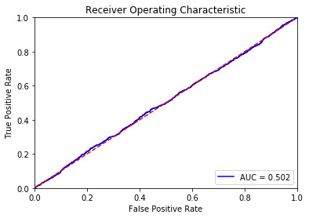

```python
evaluate(prediction_df, test_label)
plot_roc(prediction_df, test_label)
```

## 1. Random Forest - Aggregated Data

```python
from sklearn.ensemble import RandomForestClassifier
```

```python
train_dataset_prep = preprocess(train_dataset)
```

```python
train_agg_data = aggregate_data(train_dataset_prep)
train_agg_data = pd.merge(train_agg_data, train_label, on='bookingID', validate='1:1')

test_dataset_prep = preprocess(test_dataset)
test_agg_data = aggregate_data(test_dataset_prep)

features = train_agg_data.columns[train_agg_data.columns.str.contains("max|std|ratio")]
```

```
AUC: 0.7203291861481532
```

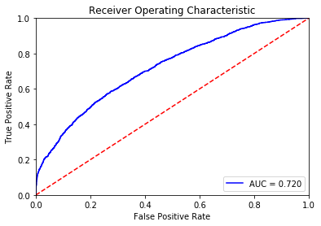

```python
cls = RandomForestClassifier(n_estimators=200, random_state=0, min_samples_leaf=75)
cls.fit(train_agg_data[features], train_agg_data.label)
pred = cls.predict_proba(test_agg_data[features])
pred = pred[:,np.argwhere(cls.classes_==1)[0][0]]
prediction_df = pd.DataFrame(data={'bookingID':test_agg_data.bookingID, 'prediction': pred})
print('AUC:',evaluate(prediction_df, test_label))
plot_roc(prediction_df, test_label);
```

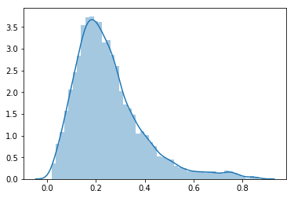

```python
sns.distplot(pred);
```

## 2. LightGBM - Logistic Stack

```python
import lightgbm as lgb
```

```python
train_dataset_prep = preprocess(train_dataset)
train_dataset_prep = pd.merge(train_dataset_prep, train_label, on='bookingID', validate='m:1')
test_dataset_prep = preprocess(test_dataset)
test_dataset_prep = pd.merge(test_dataset_prep, test_label, on='bookingID', validate='m:1')
```

```python
train_dataset_prep.columns
```

```
Index(['bookingID', 'Accuracy', 'Bearing', 'acceleration_x', 'acceleration_y',
       'acceleration_z', 'gyro_x', 'gyro_y', 'gyro_z', 'second', 'Speed',
       'sequence', 'gyro_x_stable', 'gyro_y_stable', 'gyro_z_stable',
       'gyro_x_filtered', 'gyro_y_filtered', 'gyro_z_filtered',
       'gyro_filtered_magnitude', 'gyro_filtered_std',
       'acceleration_x_gravity', 'acceleration_y_gravity',
       'acceleration_z_gravity', 'acceleration_magnitude',
       'acceleration_x_gravity_diff', 'acceleration_y_gravity_diff',
       'acceleration_z_gravity_diff', 'acceleration_gravity_diff_magnitude',
       'acceleration_std', 'acceleration_gravity_diff_std',
       'orientation_theta', 'orientation_psi', 'orientation_phi',
       'second_diff', 'Bearing_diff', 'Speed_diff', 'Bearing_dps', 'Speed_dps',
       'Accuracy_sum', 'label'],
      dtype='object')
```

```python
features = ['Accuracy', 'gyro_x_filtered', 'gyro_y_filtered', 'gyro_z_filtered', 'Speed', 'gyro_filtered_magnitude',
            'acceleration_magnitude', 'Bearing_dps', 'Speed_dps', 'Accuracy_sum',
            'acceleration_x_gravity_diff', 'acceleration_y_gravity_diff', 'acceleration_z_gravity_diff',
            'acceleration_gravity_diff_magnitude', 'orientation_theta',
            'orientation_psi', 'orientation_phi', 'second', 'acceleration_gravity_diff_std',
            'acceleration_std','gyro_filtered_std']
```

```python
cls = lgb.LGBMClassifier(boosting_type='dart',
                         objective='binary',
                         max_depth=6,
                         n_estimator=100,
                         learning_rate=0.1,
                         max_bin=100,
                         num_leaves=70,
                         lambda_l1=0.4,
                         min_data_in_leaf=150,
                         metric='auc')

cls.fit(train_dataset_prep[features], train_dataset_prep.label)
```

```
LGBMClassifier(boosting_type='dart', class_weight=None, colsample_bytree=1.0,
        importance_type='split', lambda_l1=0.4, learning_rate=0.1,
        max_bin=100, max_depth=6, metric='auc', min_child_samples=20,
        min_child_weight=0.001, min_data_in_leaf=150, min_split_gain=0.0,
        n_estimator=100, n_estimators=100, n_jobs=-1, num_leaves=70,
        objective='binary', random_state=None, reg_alpha=0.0,
        reg_lambda=0.0, silent=True, subsample=1.0,
        subsample_for_bin=200000, subsample_freq=0)
```

```python
# Comment this
y_pred = cls.predict_proba(test_dataset_prep[features])
y_pred = y_pred[:,np.argwhere(cls.classes_==1)[0][0]]
roc_auc_score(test_dataset_prep.label, y_pred)
```

```
0.6568175159159259
```

### Stacking

```python
train_pred_first = cls.predict_proba(train_dataset_prep[features])
train_pred_first = train_pred_first[:,np.argwhere(cls.classes_==1)[0][0]]

test_pred_first = cls.predict_proba(test_dataset_prep[features])
test_pred_first = test_pred_first[:,np.argwhere(cls.classes_==1)[0][0]]
```

```python
from sklearn.linear_model import LogisticRegression

train_sec = generate_second_dataset(train_dataset_prep, train_pred_first, n_column=5)
train_sec = pd.merge(train_sec, train_label, on='bookingID')
sec_features = train_sec.columns[train_sec.columns.str.contains('val')]
sec_reg = LogisticRegression(random_state=0, penalty='l2', C=0.1)
sec_reg.fit(train_sec[sec_features], train_sec.label)

test_sec = generate_second_dataset(test_dataset_prep, test_pred_first, n_column=5)
test_sec = pd.merge(test_sec, test_label, on='bookingID')
y_pred = sec_reg.predict_proba(test_sec[sec_features])
y_pred = y_pred[:,np.argwhere(cls.classes_==1)[0][0]]
prediction_df = pd.DataFrame(data={'bookingID':test_sec.bookingID, 'prediction': y_pred})

evaluate(prediction_df, test_label)
```

```
LogisticRegression(C=0.1, class_weight=None, dual=False, fit_intercept=True,
          intercept_scaling=1, max_iter=100, multi_class='ovr', n_jobs=1,
          penalty='l2', random_state=0, solver='liblinear', tol=0.0001,
          verbose=0, warm_start=False)
```

```
0.7079647586777944
```

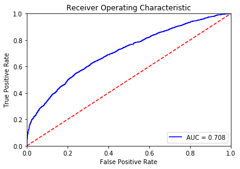

```python
plot_roc(prediction_df, test_label)
```

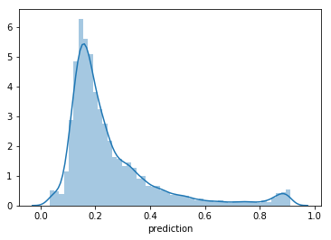

```python
sns.distplot(prediction_df.prediction)
```

## 3. CNN

We will use [1D CNN for time series data / text](https://blog.goodaudience.com/introduction-to-1d-convolutional-neural-networks-in-keras-for-time-sequences-3a7ff801a2cf)

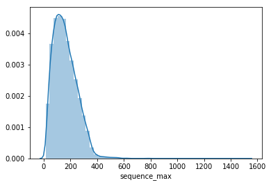

```python
sns.distplot(train_agg_data.sequence_max)
```

```python
import keras
from keras.models import Sequential, Model
from keras.layers import Dense, Dropout, Input, BatchNormalization, Flatten
from keras.layers import Conv1D, MaxPooling1D, GlobalAveragePooling1D, GlobalMaxPooling1D, Concatenate, AveragePooling1D
from keras.preprocessing.sequence import pad_sequences
from keras.regularizers import l1

def to_keras_input(dataset, features, maxlen=200) -> (list, pd.DataFrame):
    dataset_seq = dataset[
        list(set(['bookingID','second'] + features))
    ].groupby('bookingID').apply(
        lambda x: x.sort_values(by='second')[features].values.tolist()
    )
    booking_ids = pd.DataFrame({'idx': range(len(dataset_seq.index)) ,'bookingID':dataset_seq.index})
    dataset_seq = pad_sequences(dataset_seq, maxlen=maxlen, padding='pre', dtype=float, truncating='pre', value=0.0)
    return dataset_seq, booking_ids

def create_model_cnn1(dataset):
    num_seq = len(dataset[0])
    num_features = len(dataset[0][0])

    model_m = Sequential()
    model_m.add(Conv1D(16, 3, activation='relu', input_shape=(num_seq, num_features)))
    model_m.add(MaxPooling1D(3))
    model_m.add(Conv1D(32, 3, activation='relu', input_shape=(num_seq, num_features)))
    model_m.add(MaxPooling1D(3))
    model_m.add(Conv1D(64, 3, activation='relu', input_shape=(num_seq, num_features)))
    model_m.add(MaxPooling1D(3))
    model_m.add(GlobalAveragePooling1D())
    model_m.add(Dropout(0.2))
    model_m.add(Dense(16, activation='sigmoid'))
    model_m.add(Dense(1, activation='sigmoid'))
    print(model_m.summary())
    return model_m

def create_model_cnn_2(dataset):
    num_seq = len(dataset[0])
    num_features = len(dataset[0][0])

    inpt = Input(shape=(num_seq, num_features))

    convs = []

    conv1 = Conv1D(8, 1, activation='relu')(inpt)
    pool1 = GlobalMaxPooling1D()(conv1)
    convs.append(pool1)

    conv2 = Conv1D(8, 3, activation='relu')(inpt)
    pool2_1 = AveragePooling1D(pool_size=5)(conv2)
    conv2_1 = Conv1D(16, 3, activation='relu')(pool2_1)
    pool2_2 = GlobalMaxPooling1D()(conv2_1)
    convs.append(pool2_2)


    out = Concatenate()(convs)
    first_segment_model = Model(inputs=[inpt], outputs=[out])

    model = Sequential()
    model.add(first_segment_model)
    model.add(Dropout(0.2))
    model.add(Dense(16, activation='sigmoid'))
    model.add(Dense(1, activation='sigmoid'))

    print(first_segment_model.summary())
    print(model.summary())
    return model
```

```python
features = ['acceleration_x', 'acceleration_y', 'acceleration_z', 'acceleration_gravity_diff_magnitude',
            'Bearing', 'gyro_x_filtered', 'gyro_y_filtered', 'gyro_z_filtered', 'gyro_filtered_magnitude',
            'Speed', 'Accuracy', 'second', 'second_diff', 'orientation_theta', 'orientation_psi', 'orientation_phi']

train_feature_cnn = train_dataset_prep.copy()

train_feature_cnn[['acceleration_x', 'acceleration_y', 'acceleration_z']] = \
    train_feature_cnn[['acceleration_x', 'acceleration_y', 'acceleration_z']] / 10.0
train_feature_cnn['Bearing'] = train_feature_cnn['Bearing'] / 360.0
train_feature_cnn[['orientation_theta', 'orientation_psi', 'orientation_phi']] = \
    train_feature_cnn[['orientation_theta', 'orientation_psi', 'orientation_phi']] / 180.0
train_feature_cnn['Speed'] = train_feature_cnn['Speed'] / 35
train_feature_cnn['second'] = train_feature_cnn['second'] / 1750
train_feature_cnn['second_diff'] = train_feature_cnn['second_diff'] / 30
train_feature_cnn['Accuracy'] = train_feature_cnn['Accuracy'] / 15

train_feature_cnn, train_booking_ids = to_keras_input(train_feature_cnn, features, maxlen=200)
```

```python
model = create_model_cnn_2(train_feature_cnn)
model.compile(loss='binary_crossentropy',
              optimizer='adam', metrics=['binary_accuracy'])
train_seqlabel = pd.merge(train_booking_ids, train_label, on='bookingID').label


callbacks_list = [
    keras.callbacks.EarlyStopping(monitor='binary_accuracy', patience=3)
]
history = model.fit(train_feature_cnn,
                    np.array(train_seqlabel).reshape((-1,1)),
                    batch_size=4,
                    epochs=50,
                    callbacks=callbacks_list,
                    validation_split=0.2,
                    verbose=1)
```

```
__________________________________________________________________________________________________
Layer (type)                    Output Shape         Param #     Connected to
==================================================================================================
input_1 (InputLayer)            (None, 200, 16)      0
__________________________________________________________________________________________________
conv1d_2 (Conv1D)               (None, 198, 8)       392         input_1[0][0]
__________________________________________________________________________________________________
average_pooling1d_1 (AveragePoo (None, 39, 8)        0           conv1d_2[0][0]
__________________________________________________________________________________________________
conv1d_1 (Conv1D)               (None, 200, 8)       136         input_1[0][0]
__________________________________________________________________________________________________
conv1d_3 (Conv1D)               (None, 37, 16)       400         average_pooling1d_1[0][0]
__________________________________________________________________________________________________
global_max_pooling1d_1 (GlobalM (None, 8)            0           conv1d_1[0][0]
__________________________________________________________________________________________________
global_max_pooling1d_2 (GlobalM (None, 16)           0           conv1d_3[0][0]
__________________________________________________________________________________________________
concatenate_1 (Concatenate)     (None, 24)           0           global_max_pooling1d_1[0][0]
                                                                 global_max_pooling1d_2[0][0]
==================================================================================================
Total params: 928
Trainable params: 928
Non-trainable params: 0
__________________________________________________________________________________________________
None
_________________________________________________________________
Layer (type)                 Output Shape              Param #
=================================================================
model_1 (Model)              (None, 24)                928
_________________________________________________________________
dropout_1 (Dropout)          (None, 24)                0
_________________________________________________________________
dense_1 (Dense)              (None, 16)                400
_________________________________________________________________
dense_2 (Dense)              (None, 1)                 17
=================================================================
Total params: 1,345
Trainable params: 1,345
Non-trainable params: 0
_________________________________________________________________
None
Train on 11200 samples, validate on 2800 samples
```

```python
test_feature_cnn = test_dataset_prep.copy()

test_feature_cnn[['acceleration_x', 'acceleration_y', 'acceleration_z']] = \
    test_feature_cnn[['acceleration_x', 'acceleration_y', 'acceleration_z']] / 10.0
test_feature_cnn[['gyro_x_filtered', 'gyro_y_filtered', 'gyro_z_filtered']] = \
    test_feature_cnn[['gyro_x_filtered', 'gyro_y_filtered', 'gyro_z_filtered']]
test_feature_cnn['Bearing'] = test_feature_cnn['Bearing'] / 360.0
test_feature_cnn[['orientation_theta', 'orientation_psi', 'orientation_phi']] = \
    test_feature_cnn[['orientation_theta', 'orientation_psi', 'orientation_phi']] / 180.0
test_feature_cnn['Speed'] = test_feature_cnn['Speed'] / 35
test_feature_cnn['second'] = test_feature_cnn['second'] / 1750
test_feature_cnn['second_diff'] = test_feature_cnn['second_diff'] / 30
test_feature_cnn['Accuracy'] = test_feature_cnn['Accuracy'] / 15

test_feature_cnn, test_booking_ids = to_keras_input(test_feature_cnn, features, maxlen=200)

pred = model.predict_proba(test_feature_cnn)
prediction_df = pd.DataFrame(data={'bookingID': test_booking_ids.bookingID, 'prediction': pred[:,0]})
evaluate(prediction_df, test_label)
```

```
0.7276015357055682
```

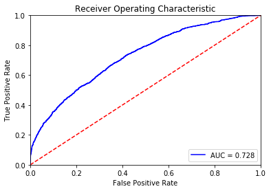

```python
plot_roc(prediction_df, test_label)
```

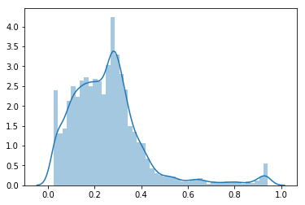

```python
sns.distplot(pd.Series(pred[:,0]))
```

## 4. CNN - Random Forest Aggregate (Best)

```python
cnn_model = Sequential()

for layer in model.layers[:-1]:
    cnn_model.add(layer)

# Freeze the layers
for layer in model.layers:
    layer.trainable = False

test_cnn_emb = cnn_model.predict_proba(test_feature_cnn)
train_cnn_emb = cnn_model.predict_proba(train_feature_cnn)
```

```python
agg_features = train_agg_data.columns[train_agg_data.columns.str.contains("max|std|ratio")]

train_data_stack = pd.concat([
    pd.Series(train_booking_ids.bookingID),
    train_agg_data[agg_features],
    pd.DataFrame(train_cnn_emb, columns=['cnn_result_'+ str(i) for i in range(len(train_cnn_emb[0]))])
], axis=1)

test_data_stack = pd.concat([
    pd.Series(test_booking_ids.bookingID),
    test_agg_data[agg_features],
    pd.DataFrame(test_cnn_emb, columns=['cnn_result_'+ str(i) for i in range(len(test_cnn_emb[0]))])
], axis=1)

train_data_stack = pd.merge(train_data_stack, train_label, on='bookingID')
train_data_stack_features = train_data_stack.columns[train_data_stack.columns != 'label']
```

### Stacking

```
RandomForestClassifier(bootstrap=True, class_weight=None, criterion='gini',
            max_depth=None, max_features='auto', max_leaf_nodes=None,
            min_impurity_decrease=0.0, min_impurity_split=None,
            min_samples_leaf=75, min_samples_split=2,
            min_weight_fraction_leaf=0.0, n_estimators=200, n_jobs=1,
            oob_score=False, random_state=0, verbose=0, warm_start=False)
```

```
AUC: 0.7345953672330409
```

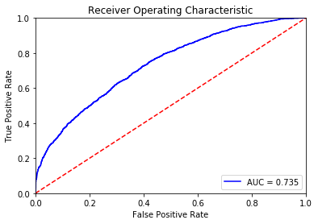

```
0.7345953672330409
```

```python
stack_clf = RandomForestClassifier(n_estimators=200, random_state=0, min_samples_leaf=75)
stack_clf.fit(train_data_stack[train_data_stack_features], train_data_stack.label)
pred = stack_clf.predict_proba(test_data_stack[train_data_stack_features])
pred = pred[:,np.argwhere(cls.classes_==1)[0][0]]

prediction_df = pd.DataFrame(data={'bookingID':test_data_stack.bookingID, 'prediction': pred})
print('AUC:',evaluate(prediction_df, test_label))
plot_roc(prediction_df, test_label);

evaluate(prediction_df, test_label)
```

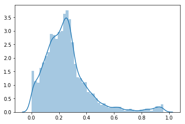

```python
sns.distplot(pred)
```